# Regression Project_SajjadRezvani

Sajjad Rezvani

03/19/2023

In this Project , I am going to create a regression model to analyze number of Covid-19 cases with Socio-economic and demographic variables to determine which variables are significantly associated with the increase in number of Covid-19 cases within the various states of United States.It is worth mentioning tha data was extracted from various sources and reports, most of which were website sources data.

# 1. Importing the dataset and observing summary of our dataset

```r
Project=read.csv("/Users/sajjad/Desktop/Github managemenet/Project/Final files/data.csv")
Project
```

| States | Cases | Population | Hospitals | Winter | Summer | Crime | Homeless | Young | GDP |
| --- | --- | --- | --- | --- | --- | --- | --- | --- | --- |
| Alabama | 834582 | 4903185 | 90 | 46.5 | 78.6 | 453.6 | 3261 | 22.2 | 203.96 |
| Alaska | 136822 | 731545 | 10 | 2.6 | 52.3 | 837.8 | 1907 | 24.6 | 50.25 |
| Arizona | 1182885 | 7278717 | 77 | 43.6 | 78.1 | 484.8 | 10007 | 22.5 | 331.35 |
| Arkansas | 515524 | 3017804 | 52 | 41.5 | 78.8 | 671.9 | 2717 | 23.2 | 120.91 |
| California | 4830954 | 39512223 | 338 | 46.2 | 73.4 | 442.0 | 151278 | 22.5 | 2832.62 |
| Colorado | 757147 | 5758736 | 57 | 25.8 | 65.2 | 423.1 | 9619 | 21.9 | 364.74 |
| Connecticut | 404969 | 3565287 | 35 | 28.5 | 69.2 | 181.6 | 3033 | 20.4 | 245.80 |
| Delaware | 145056 | 973764 | 8 | 36.1 | 74.2 | 431.9 | 921 | 20.9 | 63.55 |
| Florida | 3703111 | 21477737 | 218 | 59.4 | 81.0 | 383.6 | 28328 | 19.7 | 994.18 |
| Georgia | 1641036 | 10617423 | 113 | 47.8 | 78.7 | 400.1 | 10443 | 23.6 | 563.81 |

[output cut: 40 more lines]

```r
head(Project)
```

|  | States | Cases | Population | Hospitals | Winter | Summer | Crime | Homeless | Young | GDP |
| --- | --- | --- | --- | --- | --- | --- | --- | --- | --- | --- |
| 1 | Alabama | 834582 | 4903185 | 90 | 46.5 | 78.6 | 453.6 | 3261 | 22.2 | 203.96 |
| 2 | Alaska | 136822 | 731545 | 10 | 2.6 | 52.3 | 837.8 | 1907 | 24.6 | 50.25 |
| 3 | Arizona | 1182885 | 7278717 | 77 | 43.6 | 78.1 | 484.8 | 10007 | 22.5 | 331.35 |
| 4 | Arkansas | 515524 | 3017804 | 52 | 41.5 | 78.8 | 671.9 | 2717 | 23.2 | 120.91 |
| 5 | California | 4830954 | 39512223 | 338 | 46.2 | 73.4 | 442.0 | 151278 | 22.5 | 2832.62 |
| 6 | Colorado | 757147 | 5758736 | 57 | 25.8 | 65.2 | 423.1 | 9619 | 21.9 | 364.74 |

```r
summary(Project)
```

```
    States              Cases           Population         Hospitals          Winter
 Length:50          Min.   :  41644   Min.   :  578759   Min.   :  7.00   Min.   : 2.60
 Class :character   1st Qu.: 283026   1st Qu.: 1827712   1st Qu.: 28.00   1st Qu.:23.82
 Mode  :character   Median : 693702   Median : 4558234   Median : 59.00   Median :32.05
                    Mean   : 922616   Mean   : 6550675   Mean   : 77.12   Mean   :32.23
                    3rd Qu.:1144736   3rd Qu.: 7530849   3rd Qu.: 96.00   3rd Qu.:39.10
                    Max.   :4830954   Max.   :39512223   Max.   :367.00   Max.   :67.40
     Summer          Crime          Homeless          Young            GDP
 Min.   :52.30   Min.   :108.6   Min.   :   548   Min.   :18.30   Min.   :  29.84
 1st Qu.:66.65   1st Qu.:280.9   1st Qu.:  2315   1st Qu.:21.25   1st Qu.:  83.05
 Median :71.50   Median :373.7   Median :  4355   Median :22.15   Median : 221.57
 Mean   :71.19   Mean   :384.0   Mean   : 11113   Mean   :22.22   Mean   : 381.55
 3rd Qu.:75.55   3rd Qu.:457.4   3rd Qu.:  9543   3rd Qu.:23.20   3rd Qu.: 486.33
 Max.   :81.10   Max.   :837.8   Max.   :151278   Max.   :29.00   Max.   :2832.62
```

### As indicated above, variables are: # of covid-19 Cases,Population of each state, Number of hospitals in each state, Average winter temperature in each state, Average summer temperature in each state, Crime rate per 100,000 people in each state (Proxy for defiance from COVID-19 protocols and orders), Number of homeless people in each state, Percentage of population that are under 18 years, GDP of each state.

# 2. Data Preprocessing and developing the multiple regression model

```r
sum(is.na(Project)) #checking the missing values
```

```
[1] 0
```

```r
dat <- Project[,2:10]# Removing the "States" column

mlr <- lm(Cases ~. ,data=dat) # developing linear regression model
summary(mlr)
```

```
Call:
lm(formula = Cases ~ ., data = dat)

Residuals:
    Min      1Q  Median      3Q     Max
-284118  -53120   16741   60141  334650

Coefficients:
              Estimate Std. Error t value Pr(>|t|)
(Intercept) -7.603e+05  4.055e+05  -1.875 0.067903 .
Population   2.068e-01  2.367e-02   8.735 6.65e-11 ***
Hospitals    1.532e+03  1.365e+03   1.123 0.268155
Winter      -3.272e+03  2.800e+03  -1.168 0.249374
Summer       8.381e+03  6.307e+03   1.329 0.191196
Crime        3.505e+01  1.427e+02   0.246 0.807191
Homeless     3.154e+00  2.735e+00   1.153 0.255466
Young        9.826e+03  1.131e+04   0.869 0.390091
GDP         -1.436e+03  3.701e+02  -3.879 0.000373 ***
---
Signif. codes:  0 ‘***’ 0.001 ‘**’ 0.01 ‘*’ 0.05 ‘.’ 0.1 ‘ ’ 1

Residual standard error: 135600 on 41 degrees of freedom
Multiple R-squared:  0.9851,    Adjusted R-squared:  0.9821
F-statistic: 337.8 on 8 and 41 DF,  p-value: < 2.2e-16
```

### The model depicted and adjusted R-square of 0.9821 and an F-Statistic of 337.8 with P-value of < 2.2e-16 which depicts that’s there is a significant relationship between at least one of the variables and estimated mean of the COVID-19 cases.From the above we can see the variables “Population” and “GDP” are linearly significant.

# 3. Checking linearity assumptions

## 3.1 Scatter plot

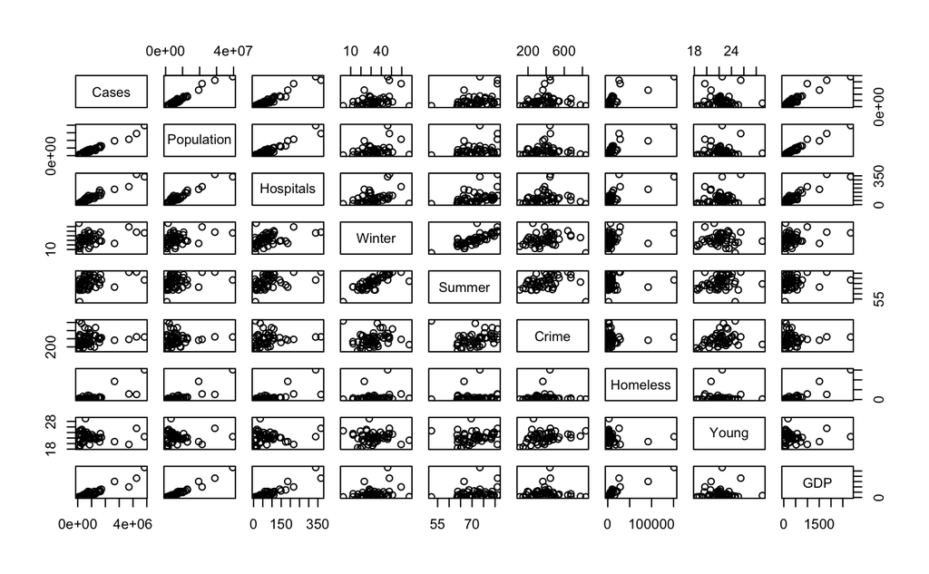

```r
pairs(dat)
```

### After inspecting scatter plots , we found out that there is no linear relationship between response variable and some of the predictors like Winter, Summer, Crime, Homeless and Young. So,it might be solved by a transformation.

## 3.2 Checking for zero mean and constant variance of random error

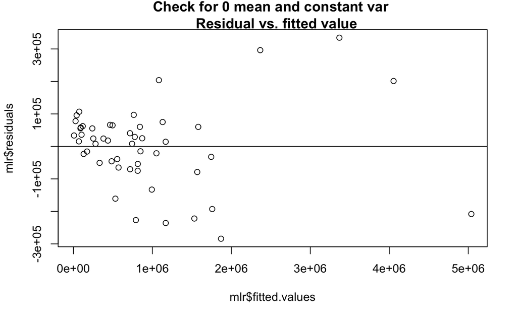

```r
plot(mlr$fitted.values, mlr$residuals,
     main = "Check for 0 mean and constant var \n  Residual vs. fitted value")
abline(h=0)
```

### As we can see in the above plot of residuals across the fitted values, in each vertical strip the average of residuals are not zero and a funnel like pattern can be seen as well. It proves that linearity assumption is violated and it is not satisfied.

## 3.3 Checking for normality of random error by QQ plot, and Shapiro test

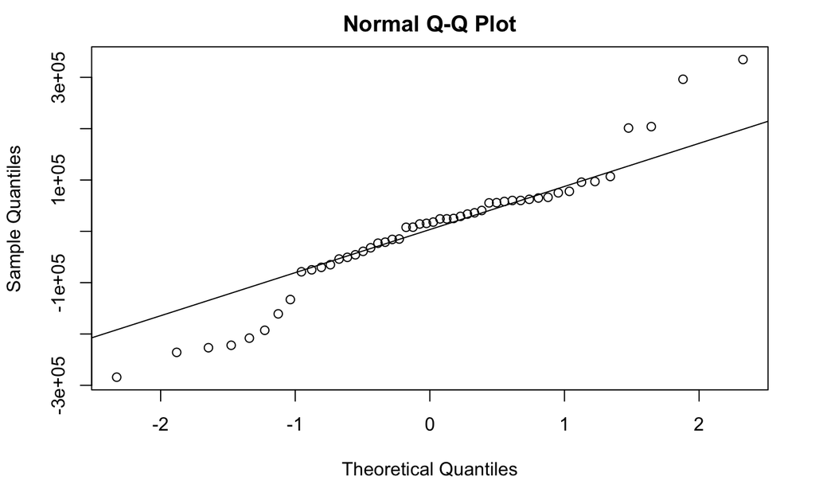

```r
qqnorm(mlr$residuals)
qqline(mlr$residuals)
```

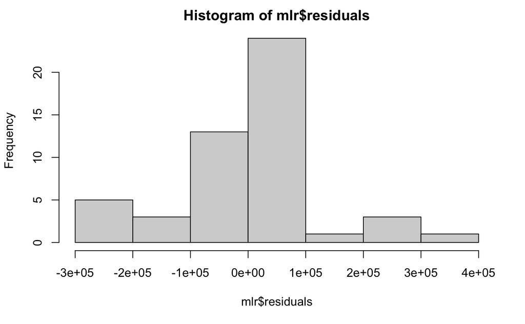

```r
hist(mlr$residuals)
```

```r
shapiro.test(mlr$residuals)
```

```
    Shapiro-Wilk normality test

data:  mlr$residuals
W = 0.94681, p-value = 0.02526
```

### From QQ plot, we obseve several observations are far from the straight line that indicates a heavy tail. These departures also prove that residuals don’t follow a normal distribution. Also by checking Shapiro test p-value = 0.02526 based on alpha=0.05 significance level , we reject null hypothesis meaning that residuals don’t follow a normal distribution.

## 3.4 Checking for correlation and variance inflation factor (VIF),multicollinearity

```r
library(car)
library(carData)
cor(Project[,-1])# removing the states column
```

```
                Cases Population  Hospitals        Winter     Summer      Crime    Homeless         Young
Cases      1.00000000 0.98325309 0.96745621  3.953325e-01 0.38567184 0.11840278  0.75200652  4.823684e-02
Population 0.98325309 1.00000000 0.95842756  3.524649e-01 0.30890199 0.07662083  0.81996693  1.766184e-02
Hospitals  0.96745621 0.95842756 1.00000000  4.075013e-01 0.43799041 0.15266527  0.68322123  9.294893e-02
Winter     0.39533250 0.35246487 0.40750135  1.000000e+00 0.78912556 0.13961972  0.17776053 -2.771172e-05
Summer     0.38567184 0.30890199 0.43799041  7.891256e-01 1.00000000 0.21058777  0.03816684  1.780320e-01
Crime      0.11840278 0.07662083 0.15266527  1.396197e-01 0.21058777 1.00000000  0.03581145  3.178356e-01
Homeless   0.75200652 0.81996693 0.68322123  1.777605e-01 0.03816684 0.03581145  1.00000000 -6.776778e-02
Young      0.04823684 0.01766184 0.09294893 -2.771172e-05 0.17803199 0.31783555 -0.06776778  1.000000e+00
GDP        0.94190391 0.98181912 0.91620640  2.754869e-01 0.21824484 0.04679403  0.88918081  1.833176e-02
                  GDP
Cases      0.94190391
Population 0.98181912
Hospitals  0.91620640
Winter     0.27548685
Summer     0.21824484
Crime      0.04679403
Homeless   0.88918081
Young      0.01833176
GDP        1.00000000
```

```r
vif(mlr)
```

```
Population  Hospitals     Winter     Summer      Crime   Homeless      Young        GDP
 81.540488  27.792471   3.178820   3.816674   1.301164  11.863457   1.275651  91.398357
```

### From above we can easily see some of the variables are highly correlated like GDP and Population.Based on VIF also , when it is greater than 4 , we can asy that our model suffers from multicollinearity and we need to take some actions like removing insignifcant variables or applying transformation.

## 3.5 Checking for independence of random error terms and “summer”&“winter” variables

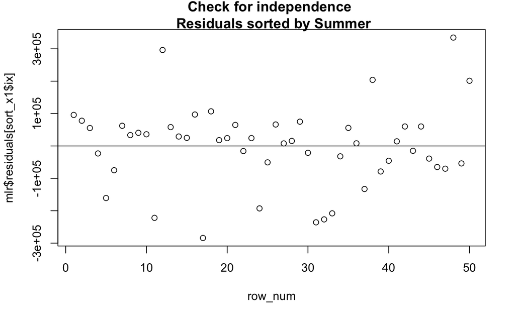

```r
row_num <- c(1:nrow(dat))
sort_x1 <- sort(dat$Summer, index.return=TRUE)
plot(row_num, mlr$residuals[sort_x1$ix],
     main = "Check for independence \n Residuals sorted by Summer")
abline(h=0)
```

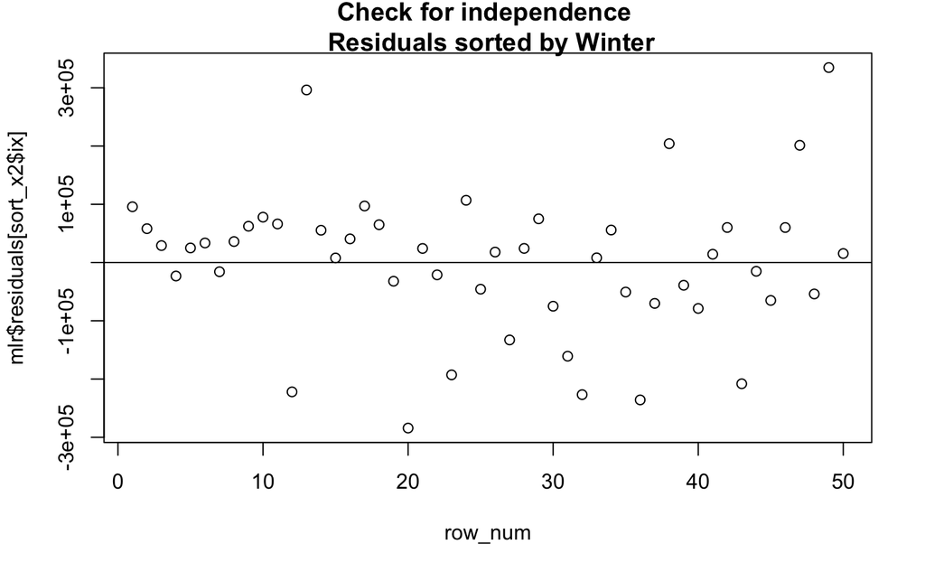

```r
# winter
sort_x2 <- sort(dat$Winter, index.return=TRUE)
plot(row_num, mlr$residuals[sort_x2$ix],
     main = "Check for independence \n Residuals sorted by Winter")
abline(h=0)
```

### Another assumption we need to prove is that error terms are indepedent while considering the above plots, a pattern can be seen and average of residuals in each vertical stripe is not zero that shows our linearity assumption is not satisfied and there is no linear relationship between the regressors and response variable.The next step is to get transformation to solve this problem.

# 4. Transformation

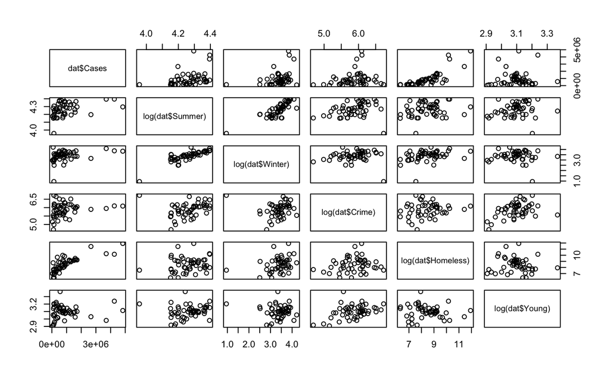

```r
pairs(dat$Cases ~ log(dat$Summer)+log(dat$Winter)+log(dat$Crime)+log(dat$Homeless)+log(dat$Young))
```

# 5. Working with new transformed dataset for fitting new MLR and checking correlations and VIF

```r
dat_tran <- read.csv("/Users/sajjad/Desktop/Github managemenet/Project/Final files/data_transformed.csv")

dat2<- dat_tran[,2:10]
head(dat2)
```

|  | Cases | Population | Hospitals | Log_winter | Log_summer | Log_Crime | Log_homeless | Log_young | GDP |
| --- | --- | --- | --- | --- | --- | --- | --- | --- | --- |
| 1 | 834582 | 4903185 | 90 | 1.6674530 | 1.895423 | 2.656673 | 3.513351 | 1.346353 | 203.96 |
| 2 | 136822 | 731545 | 10 | 0.4149733 | 1.718502 | 2.923140 | 3.280351 | 1.390935 | 50.25 |
| 3 | 1182885 | 7278717 | 77 | 1.6394865 | 1.892651 | 2.685563 | 4.000304 | 1.352183 | 331.35 |
| 4 | 515524 | 3017804 | 52 | 1.6180481 | 1.896526 | 2.827305 | 3.434090 | 1.365488 | 120.91 |
| 5 | 4830954 | 39512223 | 338 | 1.6646420 | 1.865696 | 2.645422 | 5.179776 | 1.352183 | 2832.62 |
| 6 | 757147 | 5758736 | 57 | 1.4116197 | 1.814248 | 2.626443 | 3.983130 | 1.340444 | 364.74 |

```r
# fitting new mlr model by transformed data
mlr2 <- lm(Cases ~. , data=dat2)
summary(mlr2)
```

```
Call:
lm(formula = Cases ~ ., data = dat2)

Residuals:
    Min      1Q  Median      3Q     Max
-266714  -43150    8699   49383  354454

Coefficients:
               Estimate Std. Error t value Pr(>|t|)
(Intercept)  -3.713e+06  2.007e+06  -1.850   0.0715 .
Population    2.009e-01  2.328e-02   8.629 9.22e-11 ***
Hospitals     6.920e+02  1.167e+03   0.593   0.5566
Log_winter   -3.018e+05  1.840e+05  -1.641   0.1085
Log_summer    2.119e+06  1.206e+06   1.756   0.0865 .
Log_Crime     3.014e+04  1.272e+05   0.237   0.8139
Log_homeless -1.889e+04  7.386e+04  -0.256   0.7994
Log_young     1.442e+05  6.016e+05   0.240   0.8118
GDP          -1.085e+03  2.427e+02  -4.471 6.04e-05 ***
---
Signif. codes:  0 ‘***’ 0.001 ‘**’ 0.01 ‘*’ 0.05 ‘.’ 0.1 ‘ ’ 1

Residual standard error: 134500 on 41 degrees of freedom
Multiple R-squared:  0.9853,    Adjusted R-squared:  0.9824
F-statistic: 343.3 on 8 and 41 DF,  p-value: < 2.2e-16
```

```r
vif(mlr2)
```

```
  Population    Hospitals   Log_winter   Log_summer    Log_Crime Log_homeless    Log_young          GDP
   80.148617    20.659471     4.450115     5.565651     1.450116     3.904815     1.372196    39.926439
```

```r
cor(dat2)
```

```
                  Cases Population Hospitals  Log_winter Log_summer  Log_Crime Log_homeless   Log_young
Cases        1.00000000 0.98325309 0.9674562  0.34052042  0.3776368 0.20506019   0.79108157  0.05615474
Population   0.98325309 1.00000000 0.9584276  0.31540768  0.3052034 0.16129789   0.82179146  0.02676928
Hospitals    0.96745621 0.95842756 1.0000000  0.36696507  0.4290148 0.23937725   0.75514955  0.10352924
Log_winter   0.34052042 0.31540768 0.3669651  1.00000000  0.8168968 0.06026197   0.32778267 -0.05630496
Log_summer   0.37763678 0.30520335 0.4290148  0.81689675  1.0000000 0.27356096   0.18668081  0.17731251
Log_Crime    0.20506019 0.16129789 0.2393773  0.06026197  0.2735610 1.00000000   0.16998793  0.40917399
Log_homeless 0.79108157 0.82179146 0.7551496  0.32778267  0.1866808 0.16998793   1.00000000 -0.06685908
Log_young    0.05615474 0.02676928 0.1035292 -0.05630496  0.1773125 0.40917399  -0.06685908  1.00000000
GDP          0.94190391 0.98181912 0.9162064  0.25263811  0.2175724 0.12455820   0.81130306  0.02630375
                    GDP
Cases        0.94190391
Population   0.98181912
Hospitals    0.91620640
Log_winter   0.25263811
Log_summer   0.21757238
Log_Crime    0.12455820
Log_homeless 0.81130306
Log_young    0.02630375
GDP          1.00000000
```

# 6. Corrections and eliminating some varaiables from our dataset

```r
dat_c3 <- subset(dat2,select = -c(Hospitals,Log_Crime,Log_homeless,GDP)) # removing the columns Hospitals,Log_Crime,and Log_homeless and GDP
mlr_c3 <- lm(Cases ~. , data = dat_c3) # fitting new model
summary(mlr_c3)
```

```
Call:
lm(formula = Cases ~ ., data = dat_c3)

Residuals:
    Min      1Q  Median      3Q     Max
-431548  -67678  -19348   63397  681339

Coefficients:
              Estimate Std. Error t value Pr(>|t|)
(Intercept) -7.326e+06  1.790e+06  -4.093 0.000174 ***
Population   1.324e-01  3.326e-03  39.803  < 2e-16 ***
Log_winter  -4.504e+05  1.968e+05  -2.288 0.026873 *
Log_summer   4.429e+06  1.166e+06   3.798 0.000434 ***
Log_young   -1.152e+05  6.747e+05  -0.171 0.865184
---
Signif. codes:  0 ‘***’ 0.001 ‘**’ 0.01 ‘*’ 0.05 ‘.’ 0.1 ‘ ’ 1

Residual standard error: 162600 on 45 degrees of freedom
Multiple R-squared:  0.9764,    Adjusted R-squared:  0.9743
F-statistic: 465.6 on 4 and 45 DF,  p-value: < 2.2e-16
```

```r
vif(mlr_c3)
```

```
Population Log_winter Log_summer  Log_young
  1.119151   3.485813   3.557661   1.180974
```

```r
cor(dat_c3)
```

```
                Cases Population  Log_winter Log_summer   Log_young
Cases      1.00000000 0.98325309  0.34052042  0.3776368  0.05615474
Population 0.98325309 1.00000000  0.31540768  0.3052034  0.02676928
Log_winter 0.34052042 0.31540768  1.00000000  0.8168968 -0.05630496
Log_summer 0.37763678 0.30520335  0.81689675  1.0000000  0.17731251
Log_young  0.05615474 0.02676928 -0.05630496  0.1773125  1.00000000
```

## In this new mlr model, vif is no longer an issue. Given that our model doesn’t suffers from multicollinearity.

# 7. Variable Selection using Stepwise bidirection on the previous model we built(metric: adjusted Rsquare)

```r
library(StepReg)
stepwise(dat_c3, y="Cases", selection = "bidirection", select = "adjRsq")
```

| Step | EffectEntered | EffectRemoved | EffectNumber | Select |
| --- | --- | --- | --- | --- |
| 0 | intercept |  | 1 | 0.0000000 |
| 1 | Log_summer |  | 2 | 0.1247472 |
| 2 | Population |  | 3 | 0.9659863 |

```
$variate
[1] "intercept"  "Log_summer" "Population"
```

```r
mlr_bid <- lm(Cases ~ Log_summer + Population, data = dat_c3)
summary(mlr_bid)
```

```
Call:
lm(formula = Cases ~ Log_summer + Population, data = dat_c3)

Residuals:
    Min      1Q  Median      3Q     Max
-458282  -62038  -13103   63731  685474

Coefficients:
              Estimate Std. Error t value Pr(>|t|)
(Intercept) -4.211e+06  1.241e+06  -3.392  0.00142 **
Log_summer   2.309e+06  6.742e+05   3.424  0.00129 **
Population   1.314e-01  3.429e-03  38.327  < 2e-16 ***
---
Signif. codes:  0 ‘***’ 0.001 ‘**’ 0.01 ‘*’ 0.05 ‘.’ 0.1 ‘ ’ 1

Residual standard error: 168900 on 47 degrees of freedom
Multiple R-squared:  0.9734,    Adjusted R-squared:  0.9723
F-statistic: 860.5 on 2 and 47 DF,  p-value: < 2.2e-16
```

## Based on the stepwise bidirection variable selection , selected variables are Population and Log_summer.We fit our new model considering these two variables.